# report

survminer::ggsurvplot_facet()

Bingxin Shen

November 28 2018 19:09 UTC

This is a testing report on function ggsurvplot_facet() in the package survminer. The function misses the first interval of each survival plot.

```r
library(ggplot2)
library(magrittr)
library(ggpubr)
library(survminer)
library(survival)
source("/mnt/survminer-issues/ggsurvplot_facet_fix.R")
source("/mnt/survminer-issues/ggsurvplot_core_fix.R")
source("/mnt/survminer-issues/ggsurvplot_df_fix.R")
source("/mnt/survminer-issues/connect2origin_fix.R")
```

## Test case 1

Table 1. lungTest, the testing data for case 1. 10 data points in total.

| inst | time | status | age | sex | ph.ecog | ph.karno | pat.karno | meal.cal | wt.loss |
| --- | --- | --- | --- | --- | --- | --- | --- | --- | --- |
| 3 | 306 | 2 | 74 | 1 | 1 | 90 | 100 | 1175 | NA |
| 3 | 455 | 2 | 68 | 2 | 1 | 90 | 90 | 1225 | 15 |
| 3 | 1010 | 1 | 56 | 2 | 1 | 90 | 90 | NA | 15 |
| 5 | 210 | 2 | 57 | 1 | 1 | 90 | 60 | 1150 | 11 |
| 1 | 883 | 2 | 60 | 1 | 1 | 100 | 90 | NA | 0 |
| 12 | 1022 | 1 | 74 | 1 | 2 | 50 | 80 | 513 | 0 |
| 7 | 310 | 2 | 68 | 2 | 2 | 70 | 60 | 384 | 10 |
| 11 | 361 | 2 | 71 | 2 | 2 | 60 | 80 | 538 | 1 |
| 1 | 218 | 2 | 53 | 1 | 2 | 70 | 80 | 825 | 16 |
| 7 | 166 | 2 | 61 | 1 | 2 | 70 | 70 | 271 | 34 |

One can plot the survival plots for these 10 data points in lungTest by different sex:

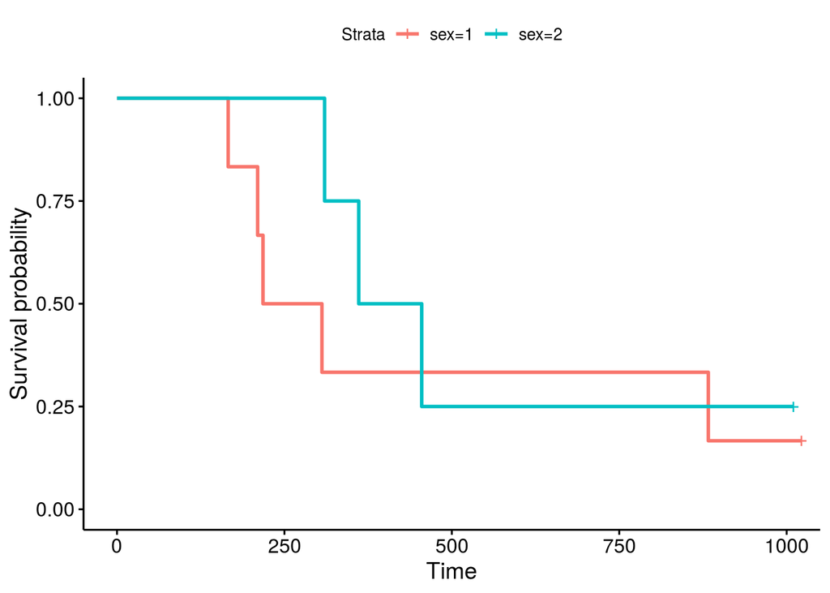

```r
survfit(Surv(time, status) ~ sex, lungTest) %>%
    ggsurvplot()  # Drawing survival curves
```

One can further facet the sex=1 and sex=2 plots by ph.ecog values:

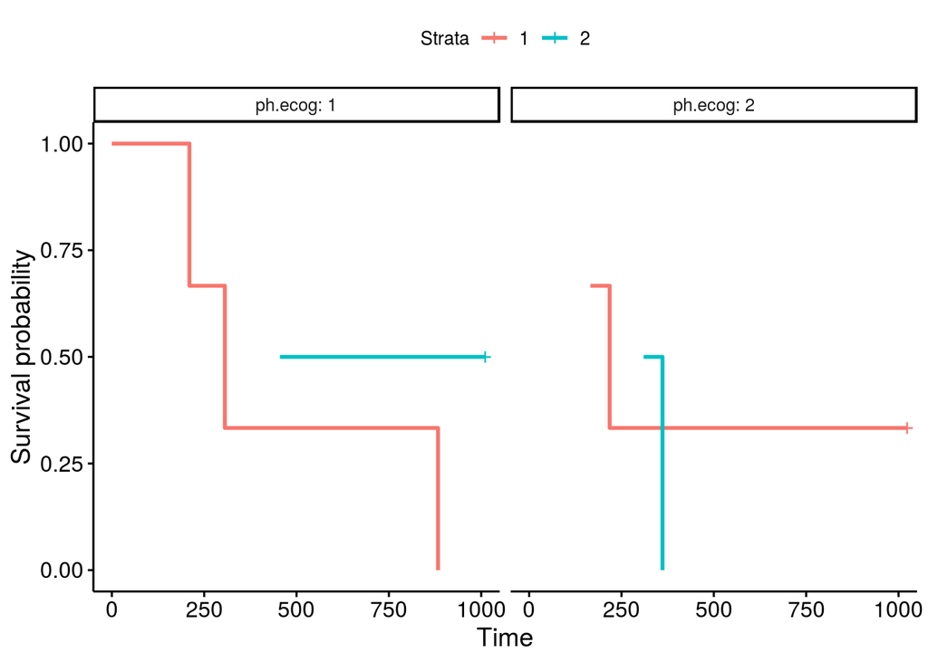

```r
survfit(Surv(time, status) ~ sex, lungTest) %>%
    ggsurvplot_facet(lungTest, facet.by="ph.ecog")
```

Here comes the problem. The function ggsurvplot_facet() missed the first intervals for each survival plot. It was caused by the returning dataframe .$data, where the starting point was not set correctly, shown in the table below. Pay attention to the first 4 rows and the last 2 columns, sex and ph.ecog values are not set correctly, compare to the column strata values.

```r
results <- ggsurvplot_facet(survfit(Surv(time, status) ~ sex, lungTest), lungTest, facet.by="ph.ecog")
results.data <- results$data
```

Table 2. Returned results.data from ggsurvplot_facet(), where the first 4 rows do not have correct strata and facet values.

| time | n.risk | n.event | n.censor | surv | std.err | upper | lower | strata | sex | ph.ecog |
| --- | --- | --- | --- | --- | --- | --- | --- | --- | --- | --- |
| 0 | 3 | 0 | 0 | 1.0000000 | 0.0000000 | 1 | 1.0000000 | sex=1, ph.ecog=1 | 1 | 1 |
| 0 | 3 | 0 | 0 | 1.0000000 | 0.0000000 | 1 | 1.0000000 | sex=1, ph.ecog=2 | 1 | 1 |
| 0 | 3 | 0 | 0 | 1.0000000 | 0.0000000 | 1 | 1.0000000 | sex=2, ph.ecog=1 | 1 | 1 |
| 0 | 3 | 0 | 0 | 1.0000000 | 0.0000000 | 1 | 1.0000000 | sex=2, ph.ecog=2 | 1 | 1 |
| 210 | 3 | 1 | 0 | 0.6666667 | 0.4082483 | 1 | 0.2995071 | sex=1, ph.ecog=1 | 1 | 1 |
| 306 | 2 | 1 | 0 | 0.3333333 | 0.8164966 | 1 | 0.0672784 | sex=1, ph.ecog=1 | 1 | 1 |
| 883 | 1 | 1 | 0 | 0.0000000 | Inf | NA | NA | sex=1, ph.ecog=1 | 1 | 1 |
| 166 | 3 | 1 | 0 | 0.6666667 | 0.4082483 | 1 | 0.2995071 | sex=1, ph.ecog=2 | 1 | 2 |
| 218 | 2 | 1 | 0 | 0.3333333 | 0.8164966 | 1 | 0.0672784 | sex=1, ph.ecog=2 | 1 | 2 |
| 1022 | 1 | 0 | 1 | 0.3333333 | 0.8164966 | 1 | 0.0672784 | sex=1, ph.ecog=2 | 1 | 2 |
| 455 | 2 | 1 | 0 | 0.5000000 | 0.7071068 | 1 | 0.1250488 | sex=2, ph.ecog=1 | 2 | 1 |
| 1010 | 1 | 0 | 1 | 0.5000000 | 0.7071068 | 1 | 0.1250488 | sex=2, ph.ecog=1 | 2 | 1 |
| 310 | 2 | 1 | 0 | 0.5000000 | 0.7071068 | 1 | 0.1250488 | sex=2, ph.ecog=2 | 2 | 2 |
| 361 | 1 | 1 | 0 | 0.0000000 | Inf | NA | NA | sex=2, ph.ecog=2 | 2 | 2 |

The function, that causes the problem of missing the first interval in a survival plot, was function .connect2origin(), which was called by ggsurvplot_df(), which was called by ggsurvplot_core(), which was called by ggsurvplot_facet().

The orginial span .connect2origin() is as follows:

```r
.connect2origin <- function (d, fit, data = NULL)
{
    base <- d[1, , drop = FALSE]
    base[intersect(c("time", "n.censor", "std.err", "n.event"),
        colnames(base))] <- 0
    base[c("surv", "upper", "lower")] <- 1
    n.strata <- length(levels(d$strata))
    if (n.strata > 1) {
        strata <- levels(d$strata)
        base <- base[rep(1, n.strata), , drop = FALSE]
        row.names(base) <- 1:nrow(base)
        base$strata <- strata
        base$strata <- factor(strata, levels = strata)
        if (!missing(fit)) {
            if (!inherits(fit, "survfit.cox")) {
                variables <- .get_variables(base$strata, fit,
                  data)
                for (variable in variables) base[[variable]] <- .get_variable_value(variable,
                  base$strata, fit, data)
            }
        }
    }
    d <- rbind(base, d)
    d
}
```

Here is how .connect2origin() works on the testing data with already processed dataframe df:

Table 3. df, the processed testing data as input of .connect2origin().

| time | n.risk | n.event | n.censor | surv | std.err | upper | lower | strata | sex | ph.ecog |
| --- | --- | --- | --- | --- | --- | --- | --- | --- | --- | --- |
| 210 | 3 | 1 | 0 | 0.6666667 | 0.4082483 | 1 | 0.2995071 | sex=1, ph.ecog=1 | 1 | 1 |
| 306 | 2 | 1 | 0 | 0.3333333 | 0.8164966 | 1 | 0.0672784 | sex=1, ph.ecog=1 | 1 | 1 |
| 883 | 1 | 1 | 0 | 0.0000000 | Inf | NA | NA | sex=1, ph.ecog=1 | 1 | 1 |
| 166 | 3 | 1 | 0 | 0.6666667 | 0.4082483 | 1 | 0.2995071 | sex=1, ph.ecog=2 | 1 | 2 |
| 218 | 2 | 1 | 0 | 0.3333333 | 0.8164966 | 1 | 0.0672784 | sex=1, ph.ecog=2 | 1 | 2 |
| 1022 | 1 | 0 | 1 | 0.3333333 | 0.8164966 | 1 | 0.0672784 | sex=1, ph.ecog=2 | 1 | 2 |
| 455 | 2 | 1 | 0 | 0.5000000 | 0.7071068 | 1 | 0.1250488 | sex=2, ph.ecog=1 | 2 | 1 |
| 1010 | 1 | 0 | 1 | 0.5000000 | 0.7071068 | 1 | 0.1250488 | sex=2, ph.ecog=1 | 2 | 1 |
| 310 | 2 | 1 | 0 | 0.5000000 | 0.7071068 | 1 | 0.1250488 | sex=2, ph.ecog=2 | 2 | 2 |
| 361 | 1 | 1 | 0 | 0.0000000 | Inf | NA | NA | sex=2, ph.ecog=2 | 2 | 2 |

```r
results <- .connect2origin(df)
```

Table 4. The ouput of .connect2origin(df).

| time | n.risk | n.event | n.censor | surv | std.err | upper | lower | strata | sex | ph.ecog |
| --- | --- | --- | --- | --- | --- | --- | --- | --- | --- | --- |
| 0 | 3 | 0 | 0 | 1.0000000 | 0.0000000 | 1 | 1.0000000 | sex=1, ph.ecog=1 | 1 | 1 |
| 0 | 3 | 0 | 0 | 1.0000000 | 0.0000000 | 1 | 1.0000000 | sex=1, ph.ecog=2 | 1 | 1 |
| 0 | 3 | 0 | 0 | 1.0000000 | 0.0000000 | 1 | 1.0000000 | sex=2, ph.ecog=1 | 1 | 1 |
| 0 | 3 | 0 | 0 | 1.0000000 | 0.0000000 | 1 | 1.0000000 | sex=2, ph.ecog=2 | 1 | 1 |
| 210 | 3 | 1 | 0 | 0.6666667 | 0.4082483 | 1 | 0.2995071 | sex=1, ph.ecog=1 | 1 | 1 |
| 306 | 2 | 1 | 0 | 0.3333333 | 0.8164966 | 1 | 0.0672784 | sex=1, ph.ecog=1 | 1 | 1 |
| 883 | 1 | 1 | 0 | 0.0000000 | Inf | NA | NA | sex=1, ph.ecog=1 | 1 | 1 |
| 166 | 3 | 1 | 0 | 0.6666667 | 0.4082483 | 1 | 0.2995071 | sex=1, ph.ecog=2 | 1 | 2 |
| 218 | 2 | 1 | 0 | 0.3333333 | 0.8164966 | 1 | 0.0672784 | sex=1, ph.ecog=2 | 1 | 2 |
| 1022 | 1 | 0 | 1 | 0.3333333 | 0.8164966 | 1 | 0.0672784 | sex=1, ph.ecog=2 | 1 | 2 |
| 455 | 2 | 1 | 0 | 0.5000000 | 0.7071068 | 1 | 0.1250488 | sex=2, ph.ecog=1 | 2 | 1 |
| 1010 | 1 | 0 | 1 | 0.5000000 | 0.7071068 | 1 | 0.1250488 | sex=2, ph.ecog=1 | 2 | 1 |
| 310 | 2 | 1 | 0 | 0.5000000 | 0.7071068 | 1 | 0.1250488 | sex=2, ph.ecog=2 | 2 | 2 |
| 361 | 1 | 1 | 0 | 0.0000000 | Inf | NA | NA | sex=2, ph.ecog=2 | 2 | 2 |

From the above results, we can see that the first 4 rows are the starting point for each plot. The last two columns do not have the correct values.

I have added a block of code to modify each starting poit per strata per facet as follows as .connect2origin_fix():

```r
.connect2origin_fix <- function(d, fit, data = NULL){

  base <- d[1, , drop = FALSE]
  base[intersect(c('time', 'n.censor', 'std.err', "n.event"), colnames(base))] <- 0
  base[c('surv', 'upper', 'lower')] <- 1.0
  n.strata <- length(levels(d$strata))

  # Connect each group to the origin
  if (n.strata > 1) {
    strata <- levels(d$strata)
    base <- base[rep(1, n.strata),, drop = FALSE]
    row.names(base) <- 1:nrow(base)
    base$strata <- strata
    base$strata <- factor(strata, levels = strata)

    #############################################################
    ##   added to modify values for each strata and facet      ##
    indStrata <- grep("strata",names(base))
    indMax    <- length(names(base))
    if(indStrata<indMax & n.strata>0){
      for (indRow in c(1:n.strata)) {
        tmpStrata = as.list(strsplit(strata[indRow], '\\,'))[[1]]
        tmpFacet  = as.numeric(gsub("\\D", "", tmpStrata))
        base[indRow, c((indStrata+1):indMax)] = tmpFacet
      }
    }
    ##                ending of the modification               ##
    #############################################################

    # update variable values
    if(!missing(fit)){
      if(!inherits(fit, "survfit.cox")){
        variables <- .get_variables(base$strata,  fit, data)
        for(variable in variables) base[[variable]] <- .get_variable_value(variable, base$strata, fit, data)
      }
    }
  }
  d <- rbind(base, d)
  d
}
```

Now the above function .connect2origin_fix() returns with correct starting points for each strata and facet:

```r
results <- .connect2origin_fix(df)
```

Table 5. The ouput of .connect2origin_fix(df).

| time | n.risk | n.event | n.censor | surv | std.err | upper | lower | strata | sex | ph.ecog |
| --- | --- | --- | --- | --- | --- | --- | --- | --- | --- | --- |
| 0 | 3 | 0 | 0 | 1.0000000 | 0.0000000 | 1 | 1.0000000 | sex=1, ph.ecog=1 | 1 | 1 |
| 0 | 3 | 0 | 0 | 1.0000000 | 0.0000000 | 1 | 1.0000000 | sex=1, ph.ecog=2 | 1 | 2 |
| 0 | 3 | 0 | 0 | 1.0000000 | 0.0000000 | 1 | 1.0000000 | sex=2, ph.ecog=1 | 2 | 1 |
| 0 | 3 | 0 | 0 | 1.0000000 | 0.0000000 | 1 | 1.0000000 | sex=2, ph.ecog=2 | 2 | 2 |
| 210 | 3 | 1 | 0 | 0.6666667 | 0.4082483 | 1 | 0.2995071 | sex=1, ph.ecog=1 | 1 | 1 |
| 306 | 2 | 1 | 0 | 0.3333333 | 0.8164966 | 1 | 0.0672784 | sex=1, ph.ecog=1 | 1 | 1 |
| 883 | 1 | 1 | 0 | 0.0000000 | Inf | NA | NA | sex=1, ph.ecog=1 | 1 | 1 |
| 166 | 3 | 1 | 0 | 0.6666667 | 0.4082483 | 1 | 0.2995071 | sex=1, ph.ecog=2 | 1 | 2 |
| 218 | 2 | 1 | 0 | 0.3333333 | 0.8164966 | 1 | 0.0672784 | sex=1, ph.ecog=2 | 1 | 2 |
| 1022 | 1 | 0 | 1 | 0.3333333 | 0.8164966 | 1 | 0.0672784 | sex=1, ph.ecog=2 | 1 | 2 |
| 455 | 2 | 1 | 0 | 0.5000000 | 0.7071068 | 1 | 0.1250488 | sex=2, ph.ecog=1 | 2 | 1 |
| 1010 | 1 | 0 | 1 | 0.5000000 | 0.7071068 | 1 | 0.1250488 | sex=2, ph.ecog=1 | 2 | 1 |
| 310 | 2 | 1 | 0 | 0.5000000 | 0.7071068 | 1 | 0.1250488 | sex=2, ph.ecog=2 | 2 | 2 |
| 361 | 1 | 1 | 0 | 0.0000000 | Inf | NA | NA | sex=2, ph.ecog=2 | 2 | 2 |

The fixed survival plot is as bellow:

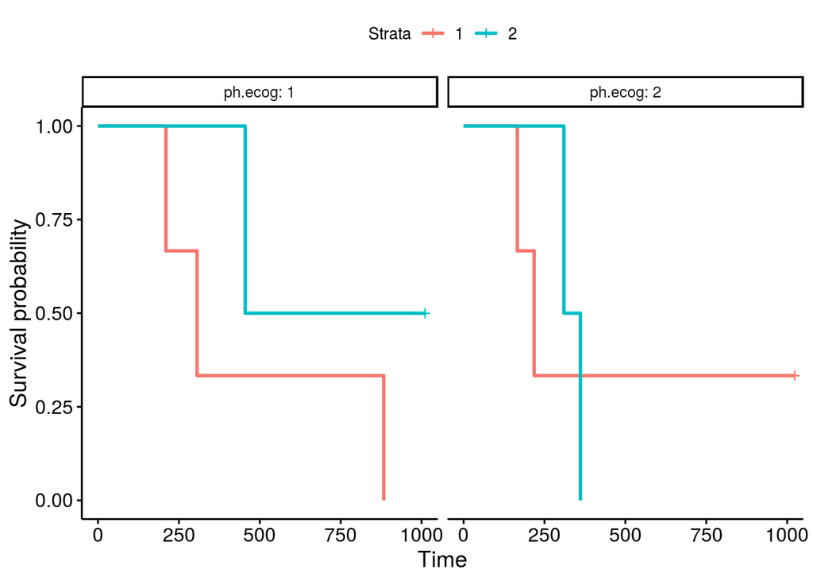

```r
survfit(Surv(time, status) ~ sex, lungTest) %>%
  ggsurvplot_facet_fix(lungTest, facet.by="ph.ecog")
```

## Test case 2

This case is with more data points, and with unbalanced strata and facets (i.e. no data point or a single data point for certain strata and facet).

```
## geom_path: Each group consists of only one observation. Do you need to
## adjust the group aesthetic?
```

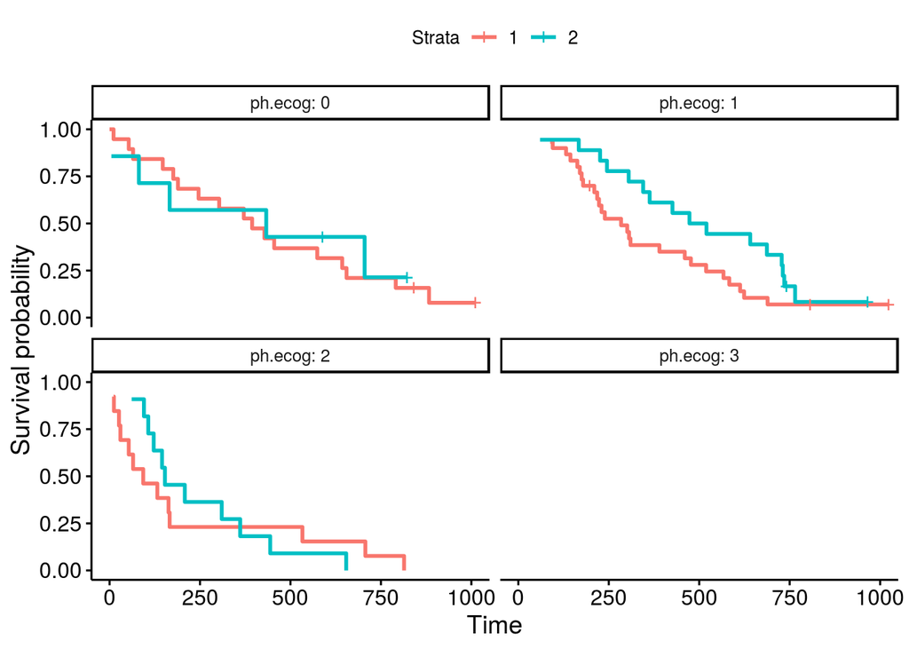

```r
require("survival")
temprcd<-100
lungTest<-lung[1:temprcd,]

# original ggsurvplot_facet missed the first intervals for each survival plot
survfit(Surv(time, status) ~ sex, lungTest) %>%
  ggsurvplot_facet(lungTest, facet.by="ph.ecog")
```

```r
tmpData <- ggsurvplot_facet(survfit(Surv(time, status) ~ sex, lungTest), lungTest, facet.by="ph.ecog")$data
```

Table 6. head(tmpData): incorrect values for different starta and facet in the rows as starting points for each plot.

| time | n.risk | n.event | n.censor | surv | std.err | upper | lower | strata | sex | ph.ecog |
| --- | --- | --- | --- | --- | --- | --- | --- | --- | --- | --- |
| 0 | 19 | 0 | 0 | 1 | 0 | 1 | 1 | sex=1, ph.ecog=0 | 1 | 0 |
| 0 | 19 | 0 | 0 | 1 | 0 | 1 | 1 | sex=1, ph.ecog=1 | 1 | 0 |
| 0 | 19 | 0 | 0 | 1 | 0 | 1 | 1 | sex=1, ph.ecog=2 | 1 | 0 |
| 0 | 19 | 0 | 0 | 1 | 0 | 1 | 1 | sex=1, ph.ecog=3 | 1 | 0 |
| 0 | 19 | 0 | 0 | 1 | 0 | 1 | 1 | sex=2, ph.ecog=0 | 1 | 0 |
| 0 | 19 | 0 | 0 | 1 | 0 | 1 | 1 | sex=2, ph.ecog=1 | 1 | 0 |
| 0 | 19 | 0 | 0 | 1 | 0 | 1 | 1 | sex=2, ph.ecog=2 | 1 | 0 |

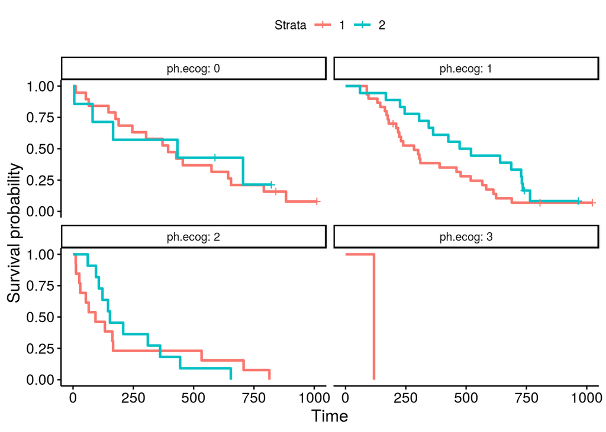

```r
# fixed plot
survfit(Surv(time, status) ~ sex, lungTest) %>%
  ggsurvplot_facet_fix(lungTest, facet.by="ph.ecog")
```

```r
tmpData <- ggsurvplot_facet_fix(survfit(Surv(time, status) ~ sex, lungTest), lungTest, facet.by="ph.ecog")$data
```

Table 7. head(tmpData): fixed/correct values for different starta and facet in the rows as starting points for each plot.

| time | n.risk | n.event | n.censor | surv | std.err | upper | lower | strata | sex | ph.ecog |
| --- | --- | --- | --- | --- | --- | --- | --- | --- | --- | --- |
| 0 | 19 | 0 | 0 | 1 | 0 | 1 | 1 | sex=1, ph.ecog=0 | 1 | 0 |
| 0 | 19 | 0 | 0 | 1 | 0 | 1 | 1 | sex=1, ph.ecog=1 | 1 | 1 |
| 0 | 19 | 0 | 0 | 1 | 0 | 1 | 1 | sex=1, ph.ecog=2 | 1 | 2 |
| 0 | 19 | 0 | 0 | 1 | 0 | 1 | 1 | sex=1, ph.ecog=3 | 1 | 3 |
| 0 | 19 | 0 | 0 | 1 | 0 | 1 | 1 | sex=2, ph.ecog=0 | 2 | 0 |
| 0 | 19 | 0 | 0 | 1 | 0 | 1 | 1 | sex=2, ph.ecog=1 | 2 | 1 |
| 0 | 19 | 0 | 0 | 1 | 0 | 1 | 1 | sex=2, ph.ecog=2 | 2 | 2 |

## Test case 3

This case is with more choices of strata and facets. Note that there is no data points for certain strata and facet.

[output not shown]

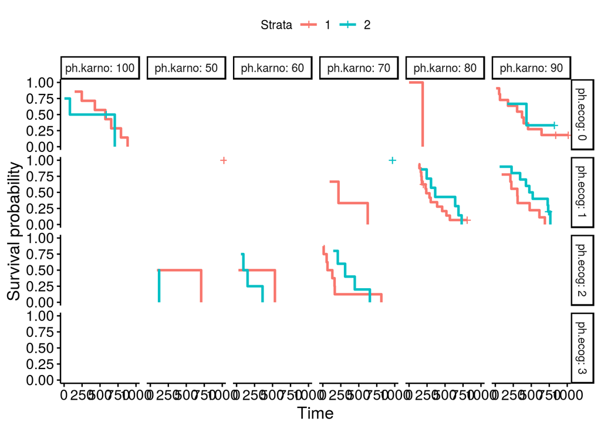

```r
require("survival")
temprcd<-100
lungTest<-lung[1:temprcd,]

# original ggsurvplot_facet missed the first intervals for each survival plot
survfit(Surv(time, status) ~  sex, lungTest) %>%
  ggsurvplot_facet(lungTest, facet.by=c("ph.ecog", "ph.karno"))
```

[output not shown]

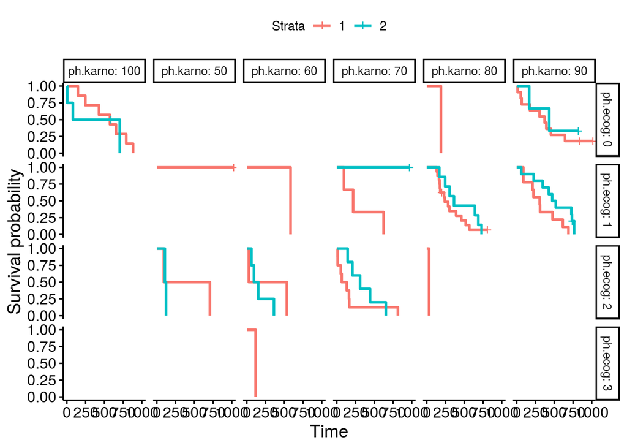

```r
# fixed plot
survfit(Surv(time, status) ~  sex, lungTest) %>%
  ggsurvplot_facet_fix(lungTest, facet.by=c("ph.ecog", "ph.karno"))
```

Table 9. Fixed/correct values for different starta and facet in the rows as starting points for each plot.

| time | n.risk | n.event | n.censor | surv | std.err | upper | lower | strata | sex | ph.ecog | ph.karno |
| --- | --- | --- | --- | --- | --- | --- | --- | --- | --- | --- | --- |
| 0 | 1 | 0 | 0 | 1 | 0 | 1 | 1 | sex=1, ph.ecog=0, ph.karno=80 | 1 | 0 | 80 |
| 0 | 1 | 0 | 0 | 1 | 0 | 1 | 1 | sex=1, ph.ecog=0, ph.karno=90 | 1 | 0 | 90 |
| 0 | 1 | 0 | 0 | 1 | 0 | 1 | 1 | sex=1, ph.ecog=0, ph.karno=100 | 1 | 0 | 100 |
| 0 | 1 | 0 | 0 | 1 | 0 | 1 | 1 | sex=1, ph.ecog=1, ph.karno=50 | 1 | 1 | 50 |
| 0 | 1 | 0 | 0 | 1 | 0 | 1 | 1 | sex=1, ph.ecog=1, ph.karno=60 | 1 | 1 | 60 |
| 0 | 1 | 0 | 0 | 1 | 0 | 1 | 1 | sex=1, ph.ecog=1, ph.karno=70 | 1 | 1 | 70 |
| 0 | 1 | 0 | 0 | 1 | 0 | 1 | 1 | sex=1, ph.ecog=1, ph.karno=80 | 1 | 1 | 80 |
| 0 | 1 | 0 | 0 | 1 | 0 | 1 | 1 | sex=1, ph.ecog=1, ph.karno=90 | 1 | 1 | 90 |
| 0 | 1 | 0 | 0 | 1 | 0 | 1 | 1 | sex=1, ph.ecog=2, ph.karno=50 | 1 | 2 | 50 |
| 0 | 1 | 0 | 0 | 1 | 0 | 1 | 1 | sex=1, ph.ecog=2, ph.karno=60 | 1 | 2 | 60 |
| 0 | 1 | 0 | 0 | 1 | 0 | 1 | 1 | sex=1, ph.ecog=2, ph.karno=70 | 1 | 2 | 70 |
| 0 | 1 | 0 | 0 | 1 | 0 | 1 | 1 | sex=1, ph.ecog=2, ph.karno=80 | 1 | 2 | 80 |
| 0 | 1 | 0 | 0 | 1 | 0 | 1 | 1 | sex=1, ph.ecog=3, ph.karno=60 | 1 | 3 | 60 |
| 0 | 1 | 0 | 0 | 1 | 0 | 1 | 1 | sex=2, ph.ecog=0, ph.karno=90 | 2 | 0 | 90 |
| 0 | 1 | 0 | 0 | 1 | 0 | 1 | 1 | sex=2, ph.ecog=0, ph.karno=100 | 2 | 0 | 100 |
| 0 | 1 | 0 | 0 | 1 | 0 | 1 | 1 | sex=2, ph.ecog=1, ph.karno=70 | 2 | 1 | 70 |
| 0 | 1 | 0 | 0 | 1 | 0 | 1 | 1 | sex=2, ph.ecog=1, ph.karno=80 | 2 | 1 | 80 |
| 0 | 1 | 0 | 0 | 1 | 0 | 1 | 1 | sex=2, ph.ecog=1, ph.karno=90 | 2 | 1 | 90 |
| 0 | 1 | 0 | 0 | 1 | 0 | 1 | 1 | sex=2, ph.ecog=2, ph.karno=50 | 2 | 2 | 50 |
| 0 | 1 | 0 | 0 | 1 | 0 | 1 | 1 | sex=2, ph.ecog=2, ph.karno=60 | 2 | 2 | 60 |
| 0 | 1 | 0 | 0 | 1 | 0 | 1 | 1 | sex=2, ph.ecog=2, ph.karno=70 | 2 | 2 | 70 |

End.